# Exam 1

## Exam 1

#### Question

1. **Theory:** Consider a linear regression of `y` on `x`. It is usually estimated with which estimation technique (three-letter abbreviation)?

   This estimator yields the best linear unbiased estimator (BLUE) under the assumptions of the Gauss-Markov theorem. Which of the following properties are required for the errors of the linear regression model under these assumptions?

   independent / zero expectation / normally distributed / identically distributed / homoscedastic

   **Application:** Using the data provided in linreg.csv estimate a linear regression of `y` on `x`. What are the estimated parameters?

   Intercept:

   Slope:

   In terms of significance at 5% level:

   `x` and `y` are not significantly correlated / `y` increases significantly with `x` / `y` decreases significantly with `x`

   **Interpretation:** Consider various diagnostic plots for the fitted linear regression model. Do you think the assumptions of the Gauss-Markov theorem are fulfilled? What are the consequences?

   **Code:** Please upload your code script that reads the data, fits the regression model, extracts the quantities of interest, and generates the diagnostic plots.

#### Solution

   **Theory:** Linear regression models are typically estimated by ordinary least squares (OLS). The Gauss-Markov theorem establishes certain optimality properties: Namely, if the errors have expectation zero, constant variance (homoscedastic), no autocorrelation and the regressors are exogenous and not linearly dependent, the OLS estimator is the best linear unbiased estimator (BLUE).

   **Application:** The estimated coefficients along with their significances are reported in the summary of the fitted regression model, showing that `x` and `y` are not significantly correlated (at 5% level).

   ```
   Call:
   lm(formula = y ~ x, data = d)

   Residuals:
        Min       1Q   Median       3Q      Max
   -0.55258 -0.15907 -0.02757  0.15782  0.74504

   Coefficients:
                Estimate Std. Error t value Pr(>|t|)
   (Intercept) -0.007988   0.024256  -0.329    0.743
   x           -0.031263   0.045420  -0.688    0.493

   Residual standard error: 0.2425 on 98 degrees of freedom
   Multiple R-squared:  0.004811,  Adjusted R-squared:  -0.005344
   F-statistic: 0.4738 on 1 and 98 DF,  p-value: 0.4929
   ```

   **Interpretation:** Considering the visualization of the data along with the diagnostic plots suggests that the assumptions of the Gauss-Markov theorem are reasonably well fulfilled.

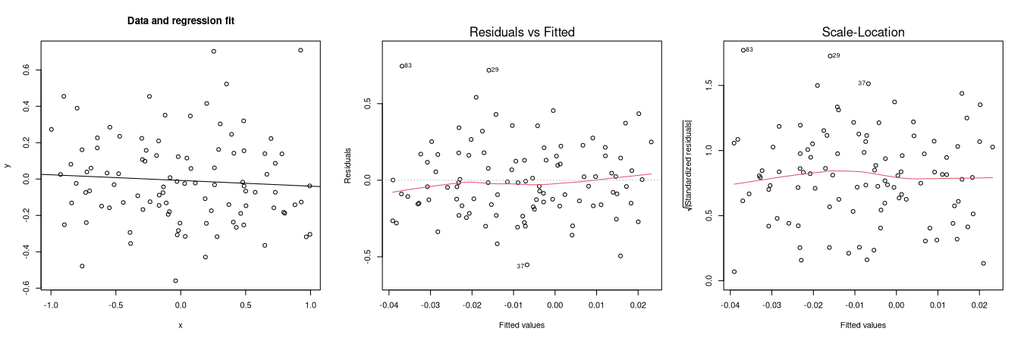

   **Code:** The analysis can be replicated in R using the following code.

   ```
   ## data
   d <- read.csv("linreg.csv")
   ## regression
   m <- lm(y ~ x, data = d)
   summary(m)
   ## visualization
   plot(y ~ x, data = d)
   abline(m)
   ## diagnostic plots
   plot(m)
   ```